# lab4a_1.1

## Wind Data

```
## Rows: 30
## Columns: 5
## $ WS   <dbl> 50, 47, 57, 38, 52, 57, 53, 62, 52, 42, 47, 40, 42, 40, 48, 50, …
## $ Temp <dbl> 77, 80, 75, 72, 71, 74, 78, 82, 82, 82, 82, 80, 81, 85, 82, 79, …
## $ H    <dbl> 67, 66, 77, 73, 75, 75, 64, 59, 60, 62, 59, 66, 68, 62, 70, 66, …
## $ In   <dbl> 78, 77, 73, 69, 78, 80, 75, 78, 75, 58, 76, 76, 71, 74, 73, 72, …
## $ O    <dbl> 15, 20, 13, 21, 12, 12, 12, 11, 12, 20, 11, 17, 20, 23, 17, 16, …
```

## Question 1.

**Generate a pairs plot of the data using pairs() or the ggpairs() function from the GGally package.**

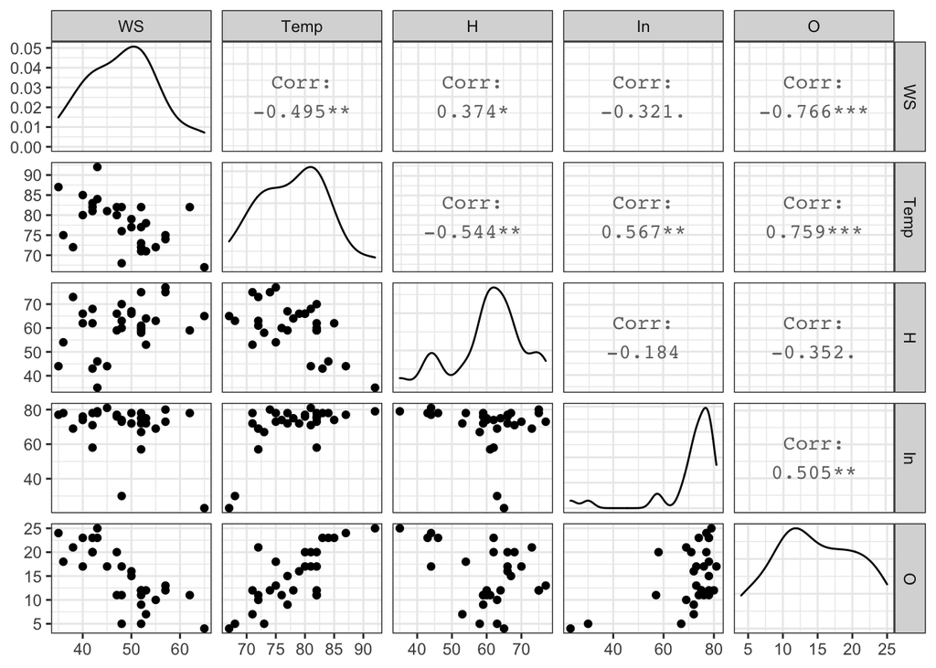

## Question 2.

**Perform a multiple regression of ozone on the other variables using lm().**

```
##
## Call:
## lm(formula = O ~ WS + Temp + H + In, data = pollut)
##
## Residuals:
##     Min      1Q  Median      3Q     Max
## -6.5861 -1.0961  0.3512  1.7570  4.0712
##
## Coefficients:
##              Estimate Std. Error t value Pr(>|t|)
## (Intercept) -15.49370   13.50647  -1.147  0.26219
## WS           -0.44291    0.08678  -5.104 2.85e-05 ***
## Temp          0.56933    0.13977   4.073  0.00041 ***
## H             0.09292    0.06535   1.422  0.16743
## In            0.02275    0.05067   0.449  0.65728
## ---
## Signif. codes:  0 '***' 0.001 '**' 0.01 '*' 0.05 '.' 0.1 ' ' 1
##
## Residual standard error: 2.92 on 25 degrees of freedom
## Multiple R-squared:  0.798,  Adjusted R-squared:  0.7657
## F-statistic: 24.69 on 4 and 25 DF,  p-value: 2.279e-08
```

## Question 3.

**Does it look like any variables can be dropped from the model? If you were doing backwards selection using the drop1() function which would you drop first?**

Yes it seems like some variables can be dropped. By looking at the (larger) p-values it seems like insolation (In) and humidity (H) can be dropped. We would drop insolation first as the p-value is larger showing a high chance of it being 0 (i.e. not as relevant to the model).

**Write down a the workflow for a formal hypothesis test to see if the coefficient for insolation is significantly different to zero.**

- **Hypothesis:** $H_0: \beta_4 = 0$ vs. $H_1: \beta_4 \neq 0$
- **Assumption:** The residuals $\epsilon_i$ are iid $N(0,\sigma^2)$ and there is a linear relationship between $y$ and $x$

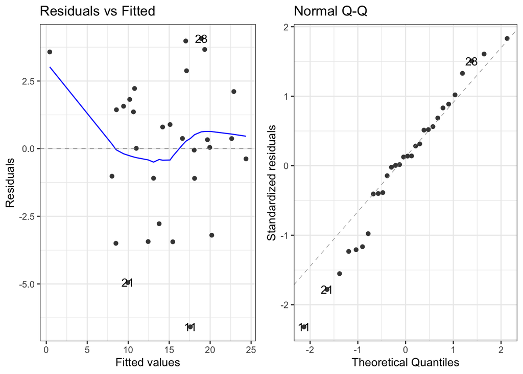

- Assumption Checking:
  - Linearity: The blue line has no obvious pattern (i.e. no smiley or frowny face)
  - Homoskedasticity: The the points are evenly spread and there is no fanning out of the points therefore, the assumption of equal error variance must also hold
  - Normallity: Most of the points lie near the QQ line with the exception of a few near the bottom. However, we can also rely on the central limit theorem.
- **Test statistic:** $T=\frac{\hat{\beta_4}}{SE(\hat{\beta_4})}\sim t_{n-p}=t_{25}$
  - where $p$ is the estimated number of intercepts including the intercept and $n$ is the sample size
- **Observed test statistic:** $t_0=\frac{0.02275}{0.05067}=0.449$ (from R output).
- **p-value:** $2P(T_{25}\geq |0.449|)=0.657$
- **Conclusion:** The p-value is larger than the 5% level of significance therefore, $H_0$ is no rejected. Thus, there is no evidence for a significant relationship between ozone and insolation. So it is dropped from the full model.

## Question 4.

**Rather than dropping variables using their individual p-values, we can instead consider using an information criterion. Use the step() function to perform selection using the AIC starting from the full model.**

```r
pollut_step = step(lm_ozone)
```

```
## Start:  AIC=68.82
## O ~ WS + Temp + H + In
##
##        Df Sum of Sq    RSS    AIC
## - In    1     1.719 214.81 67.056
## <none>              213.09 68.815
## - H     1    17.231 230.32 69.148
## - Temp  1   141.424 354.51 82.086
## - WS    1   222.041 435.13 88.233
##
## Step:  AIC=67.06
## O ~ WS + Temp + H
##
##        Df Sum of Sq    RSS    AIC
## <none>              214.81 67.056
## - H     1     20.09 234.90 67.739
## - Temp  1    216.28 431.09 85.954
## - WS    1    226.96 441.77 86.688
```

```r
pollut_step
```

```
##
## Call:
## lm(formula = O ~ WS + Temp + H, data = pollut)
##
## Coefficients:
## (Intercept)           WS         Temp            H
##    -16.6070      -0.4462       0.6019       0.0985
```

The backwards selection has dropped insolation but has kept humidity (H).

## Question 5.

**Write down the fitted model for the model selected by the step-wise procedure.**

$\hat{Ozone}=-16.6-(0.4462\times\mbox{WS})+(0.6\times\mbox{Temp})+(0.0985\times\mbox{H})$

## Question 6.

**Check the linear regression assumptions for the stepwise model.**

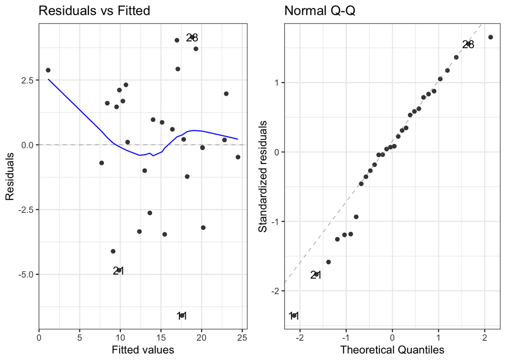

- The assumptions still hold.
  - Linearity: The blue line has no obvious pattern (i.e. no smiley nor frowny face)
  - Homoskedasticity: The points are evenly spread throughout (i.e. no fanning shape)
  - Normality: Most of the points lie on the vertical line furthermore, relying on the CLT, the assumption holds

## Question 7.

**What proportion of the variability of ozone is explained by the explanatory variables in the step-wise selected model?**

```
##
## Call:
## lm(formula = O ~ WS + Temp + H, data = pollut)
##
## Residuals:
##     Min      1Q  Median      3Q     Max
## -6.5887 -1.1686  0.1978  1.9004  4.1544
##
## Coefficients:
##              Estimate Std. Error t value Pr(>|t|)
## (Intercept) -16.60697   13.07154  -1.270    0.215
## WS           -0.44620    0.08513  -5.241 1.78e-05 ***
## Temp          0.60190    0.11764   5.117 2.47e-05 ***
## H             0.09850    0.06316   1.559    0.131
## ---
## Signif. codes:  0 '***' 0.001 '**' 0.01 '*' 0.05 '.' 0.1 ' ' 1
##
## Residual standard error: 2.874 on 26 degrees of freedom
## Multiple R-squared:  0.7964, Adjusted R-squared:  0.7729
## F-statistic: 33.89 on 3 and 26 DF,  p-value: 3.904e-09
```

Looking at the (non adjusted) $R^2$ value, we can see that around 80% of the ozone prediction can be explained by the predictor variables.

## Question 8.

**Use the model to estimate the average ozone for days when WS=40, Temp=80 and H=50. Is a confidence interval or a prediction interval most appropriate here? Write down the interval you think is most appropriate.**

- Confidence interval

```
##       fit      lwr      upr
## 1 18.6218 16.70852 20.53509
```

- Prediction interval

```
##       fit      lwr      upr
## 1 18.6218 12.41146 24.83215
```

The most appropriate interval would be the confidence interval because the question has asked us to estimate the **AVERAGE** ozone for days. If the question asked us to predict on a specific day then we would use the prediction interval.

Therefore, our confidence interval would be $(16.71,20.54)$.